# Lab 2: Plots Using ggplot2

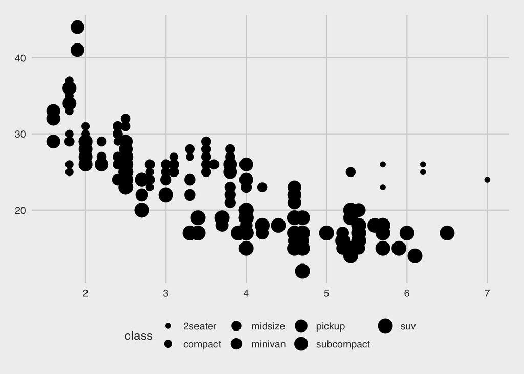

```r
ggplot(data = mpg) +
  geom_point(mapping = aes(x = displ, y = hwy, size = class)) + theme_fivethirtyeight()
```

We can facet wrap, which will make a plot for each variable we wrap by and then arrange them in a grid.

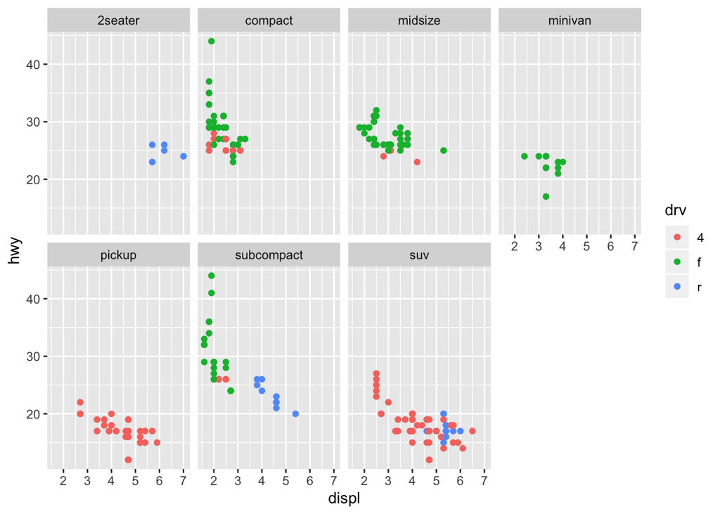

```r
ggplot(data = mpg) +
  geom_point(mapping = aes(x = displ, y = hwy, color = drv)) +
  facet_wrap(~ class, nrow = 2)
```

Of course, we can make many different types of graphs besides scatterplots using ggplot. Here is how we would fit a line through data points:

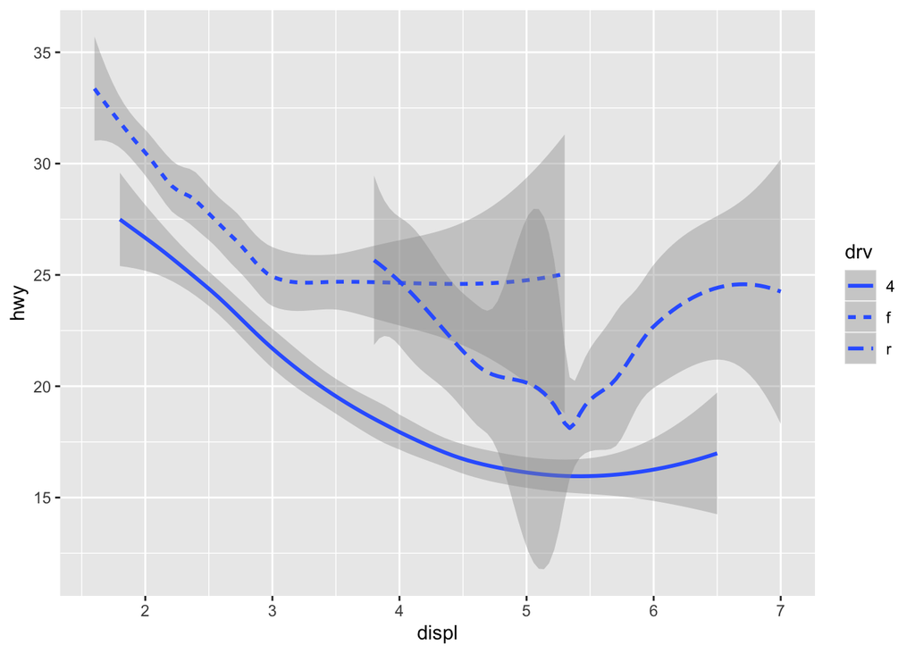

```r
ggplot(data = mpg) +
  geom_smooth(mapping = aes(x = displ, y = hwy, linetype = drv))
```

We can also combine multiple geoms by adding multiple layers.

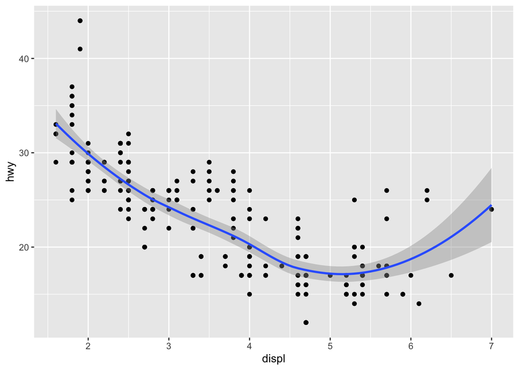

```r
ggplot(data = mpg) +
  geom_point(mapping = aes(x = displ, y = hwy)) +
  geom_smooth(mapping = aes(x = displ, y = hwy))
```

Some geoms, like boxplots, use categorical x variables.

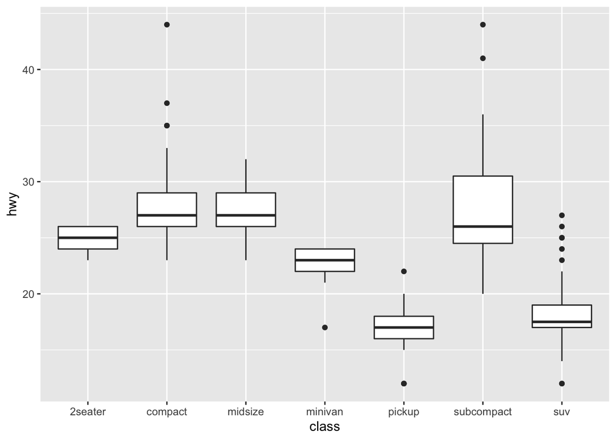

```r
ggplot(data = mpg, mapping = aes(x = class, y = hwy)) +
  geom_boxplot()
```

## Some Cool Extensions

Now that we have some basics, let’s make some cool graphs using some fun data. [Tidy Tuesday](https://github.com/rfordatascience/tidytuesday) is a weekly data science project that has a new, accessible dataset to try your tidyverse skills on. We are going to use two datasets from this github repo to make some interesting ggplots.

### Bob Ross Data

The first dataset we are going to use is [bob ross](https://github.com/rfordatascience/tidytuesday/tree/master/data/2019/2019-08-06). We can download the data into R by simply copying and pasting the `read_csv()` code found on that page.

```r
bob_ross <- read_csv("https://raw.githubusercontent.com/rfordatascience/tidytuesday/master/data/2019/2019-08-06/bob-ross.csv")
head(bob_ross, 10)
```

```
## # A tibble: 10 x 69
##    EPISODE TITLE APPLE_FRAME AURORA_BOREALIS  BARN BEACH  BOAT BRIDGE
##    <chr>   <chr>       <dbl>           <dbl> <dbl> <dbl> <dbl>  <dbl>
##  1 S01E01  "\"A…           0               0     0     0     0      0
##  2 S01E02  "\"M…           0               0     0     0     0      0
##  3 S01E03  "\"E…           0               0     0     0     0      0
##  4 S01E04  "\"W…           0               0     0     0     0      0
##  5 S01E05  "\"Q…           0               0     0     0     0      0
##  6 S01E06  "\"W…           0               0     0     0     0      0
##  7 S01E07  "\"A…           0               0     0     0     0      0
##  8 S01E08  "\"P…           0               0     0     0     0      0
##  9 S01E09  "\"S…           0               0     0     1     0      0
## 10 S01E10  "\"M…           0               0     0     0     0      0
## # … with 61 more variables: BUILDING <dbl>, BUSHES <dbl>, CABIN <dbl>,
## #   CACTUS <dbl>, CIRCLE_FRAME <dbl>, CIRRUS <dbl>, CLIFF <dbl>,
## #   CLOUDS <dbl>, CONIFER <dbl>, CUMULUS <dbl>, DECIDUOUS <dbl>,
## #   DIANE_ANDRE <dbl>, DOCK <dbl>, DOUBLE_OVAL_FRAME <dbl>, FARM <dbl>,
## #   FENCE <dbl>, FIRE <dbl>, FLORIDA_FRAME <dbl>, FLOWERS <dbl>,
## #   FOG <dbl>, FRAMED <dbl>, GRASS <dbl>, GUEST <dbl>,
## #   HALF_CIRCLE_FRAME <dbl>, HALF_OVAL_FRAME <dbl>, HILLS <dbl>,
## #   LAKE <dbl>, LAKES <dbl>, LIGHTHOUSE <dbl>, MILL <dbl>, MOON <dbl>,
## #   MOUNTAIN <dbl>, MOUNTAINS <dbl>, NIGHT <dbl>, OCEAN <dbl>,
## #   OVAL_FRAME <dbl>, PALM_TREES <dbl>, PATH <dbl>, PERSON <dbl>,
## #   PORTRAIT <dbl>, RECTANGLE_3D_FRAME <dbl>, RECTANGULAR_FRAME <dbl>,
## #   RIVER <dbl>, ROCKS <dbl>, SEASHELL_FRAME <dbl>, SNOW <dbl>,
## #   SNOWY_MOUNTAIN <dbl>, SPLIT_FRAME <dbl>, STEVE_ROSS <dbl>,
## #   STRUCTURE <dbl>, SUN <dbl>, TOMB_FRAME <dbl>, TREE <dbl>, TREES <dbl>,
## #   TRIPLE_FRAME <dbl>, WATERFALL <dbl>, WAVES <dbl>, WINDMILL <dbl>,
## #   WINDOW_FRAME <dbl>, WINTER <dbl>, WOOD_FRAMED <dbl>
```

The dataframe has Bob Ross episodes and a bunch of dummy variables equal to one if that item is included in the painting for that episode. This isn’t a super useful format for graphing so we need to clean it up a bit. The code below isn’t important for this class but if you’re curious about how I cleaned the data, it is below.

```r
bob_ross_clean <- bob_ross %>% janitor::clean_names() %>%
  gather(element, present, -episode, -title) %>%
  filter(present == 1) %>%
  mutate(title = str_to_title(str_remove_all(title, '"')),
         element = str_to_title(str_replace(element, "_", " "))) %>%
  dplyr::select(-present) %>%
  separate(episode, into = c("season", "episode"), sep = "E") %>%
  mutate(season = str_extract(season, "[:digit:]+")) %>%
  mutate_at(vars(season, episode), as.integer) %>%
  arrange(season, episode)

head(bob_ross_clean, 10)
```

```
## # A tibble: 10 x 4
##    season episode title               element
##     <int>   <int> <chr>               <chr>
##  1      1       1 A Walk In The Woods Bushes
##  2      1       1 A Walk In The Woods Deciduous
##  3      1       1 A Walk In The Woods Grass
##  4      1       1 A Walk In The Woods River
##  5      1       1 A Walk In The Woods Tree
##  6      1       1 A Walk In The Woods Trees
##  7      1       2 Mt. Mckinley        Cabin
##  8      1       2 Mt. Mckinley        Clouds
##  9      1       2 Mt. Mckinley        Conifer
## 10      1       2 Mt. Mckinley        Mountain
```

Now our data has season, episode, title and element as variables. The element column is what we are going to be interested in - these are items that appear in the painting. Let’s make a graph of the most commonly occuring elements in all of the Bob Ross paintings. To do so, we need total counts of each variable. Let’s make a new dataframe.

```r
counts <- bob_ross_clean %>% count(element, sort = TRUE) %>%
  arrange(desc(n))

head(counts, 10)
```

```
## # A tibble: 10 x 2
##    element       n
##    <chr>     <int>
##  1 Tree        361
##  2 Trees       337
##  3 Deciduous   227
##  4 Conifer     212
##  5 Clouds      179
##  6 Mountain    160
##  7 Lake        143
##  8 Grass       142
##  9 River       126
## 10 Bushes      120
```

This `counts` dataframe has the elements and the total number of times that element appears, arranged greatest to least. Let’s plot the top 15 items in a bar chart.

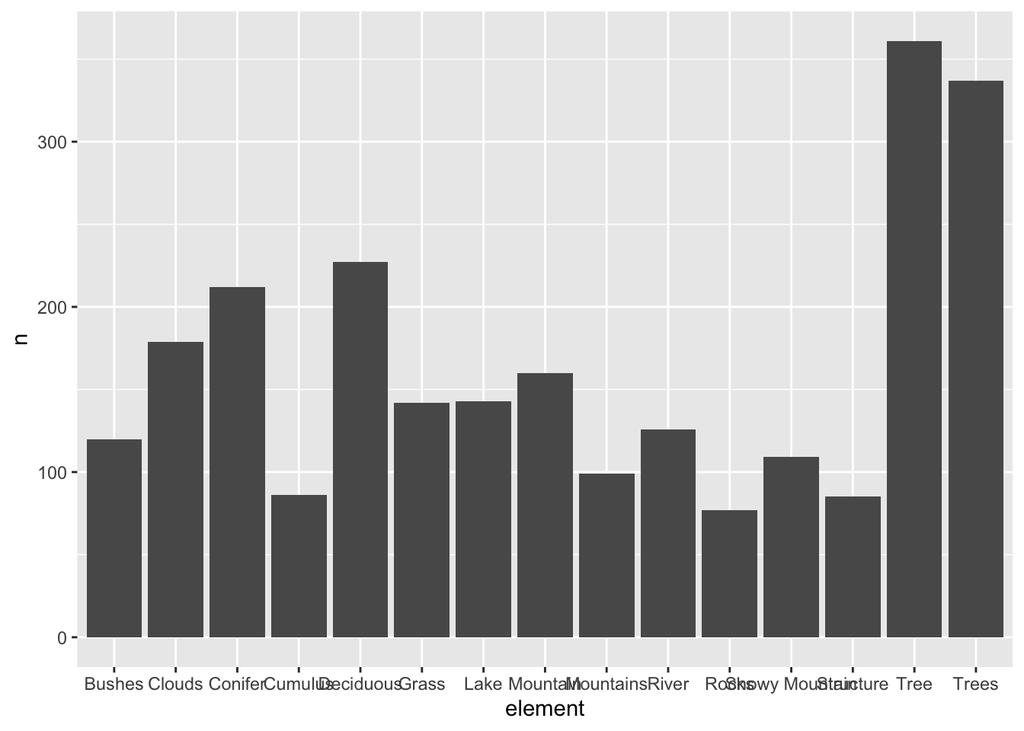

```r
plot1 <- counts %>% head(15) %>%
  ggplot(aes(element, n)) + geom_col() #+ coord_flip()

plot1
```

That is not a very pretty looking graph so let’s use our ggplot skills to make it look nicer. We can make a color palette and add that to the graph. Let’s also add a title and labels.

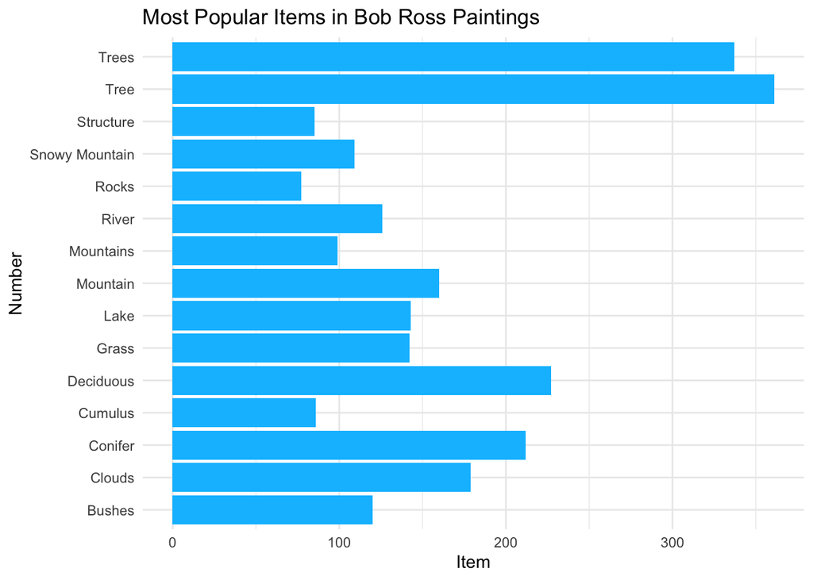

```r
my_happy_little_palette = 'deepskyblue'

plot1 <- counts %>% head(15) %>%
  ggplot(aes(element, n)) + geom_col(fill = my_happy_little_palette) + coord_flip() +
  theme_minimal() +
  labs(title = "Most Popular Items in Bob Ross Paintings",
       x = "Number",
       y = "Item")
plot1
```

Beautiful!

### UFO Sightings Data

The next dataset from the Tidy Tuesday repo contains information on global UFO sightings. You can find the information on the dataset [here](https://github.com/rfordatascience/tidytuesday/tree/master/data/2019/2019-06-25).

```r
ufo_sightings <- readr::read_csv("https://raw.githubusercontent.com/rfordatascience/tidytuesday/master/data/2019/2019-06-25/ufo_sightings.csv")
head(ufo_sightings, 10)
```

```
## # A tibble: 10 x 11
##    date_time city_area state country ufo_shape encounter_length
##    <chr>     <chr>     <chr> <chr>   <chr>                <dbl>
##  1 10/10/19… san marc… tx    us      cylinder              2700
##  2 10/10/19… lackland… tx    <NA>    light                 7200
##  3 10/10/19… chester … <NA>  gb      circle                  20
##  4 10/10/19… edna      tx    us      circle                  20
##  5 10/10/19… kaneohe   hi    us      light                  900
##  6 10/10/19… bristol   tn    us      sphere                 300
##  7 10/10/19… penarth … <NA>  gb      circle                 180
##  8 10/10/19… norwalk   ct    us      disk                  1200
##  9 10/10/19… pell city al    us      disk                   180
## 10 10/10/19… live oak  fl    us      disk                   120
## # … with 5 more variables: described_encounter_length <chr>,
## #   description <chr>, date_documented <chr>, latitude <dbl>,
## #   longitude <dbl>
```

Check out the variable names.

```r
names(ufo_sightings)
```

```
##  [1] "date_time"                  "city_area"
##  [3] "state"                      "country"
##  [5] "ufo_shape"                  "encounter_length"
##  [7] "described_encounter_length" "description"
##  [9] "date_documented"            "latitude"
## [11] "longitude"
```

And let’s check out the class of this date_time variable.

```r
class(ufo_sightings$date_time)
```

```
## [1] "character"
```

The `date_time` variable is a character. Wouldn’t it be cool if we could change this to a date format and use that in our plots? This would be helpful for time series data… Luckily, we can! The `lubridate` package allows us to format variables as dates and times. Let’s convert this variable to a date format and also filter out any NA values for the country.

```r
ufo <- ufo_sightings %>%
  mutate(date_time = parse_date_time(date_time, 'mdy_HM')) %>%
  filter(country != "NA")

head(ufo, 5)
```

```
## # A tibble: 5 x 11
##   date_time           city_area state country ufo_shape encounter_length
##   <dttm>              <chr>     <chr> <chr>   <chr>                <dbl>
## 1 1949-10-10 20:30:00 san marc… tx    us      cylinder              2700
## 2 1955-10-10 17:00:00 chester … <NA>  gb      circle                  20
## 3 1956-10-10 21:00:00 edna      tx    us      circle                  20
## 4 1960-10-10 20:00:00 kaneohe   hi    us      light                  900
## 5 1961-10-10 19:00:00 bristol   tn    us      sphere                 300
## # … with 5 more variables: described_encounter_length <chr>,
## #   description <chr>, date_documented <chr>, latitude <dbl>,
## #   longitude <dbl>
```

Now we are ready to make our plot. This plot is going to use the `ggridges` package and examines the distribution of monthly UFO sightings by country.

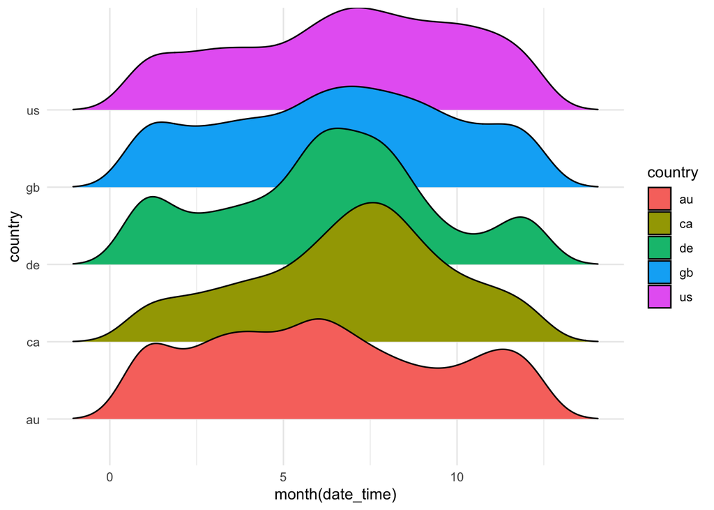

```r
ufo %>% ggplot(aes(x = month(date_time), y = country, fill = country)) + geom_density_ridges() +
  theme_minimal()
```

Because we made the `date_time` variable into a date format, we can also look at the hourly distribution of UFO sightings by country.

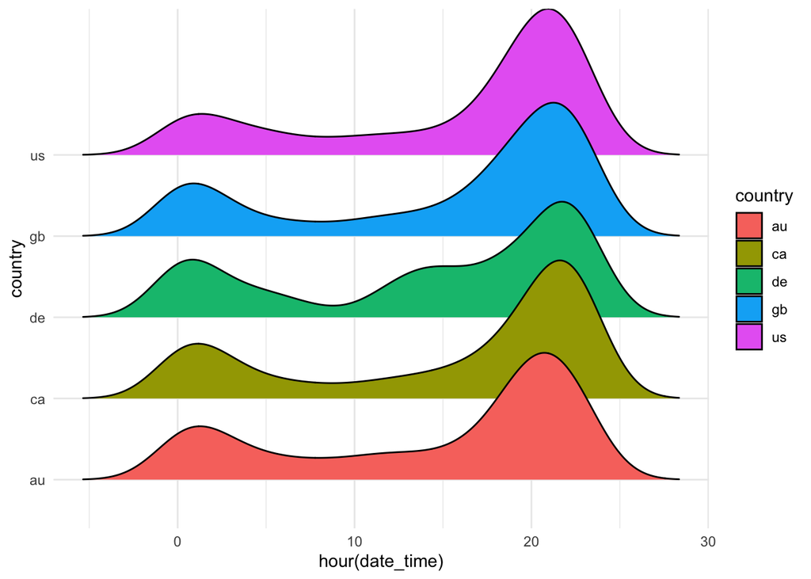

```r
ufo %>% ggplot(aes(x = hour(date_time), y = country, fill = country)) + geom_density_ridges() +
  theme_minimal()
```

Next, let’s make a time series line plot to look at the total UFO sightings over time.

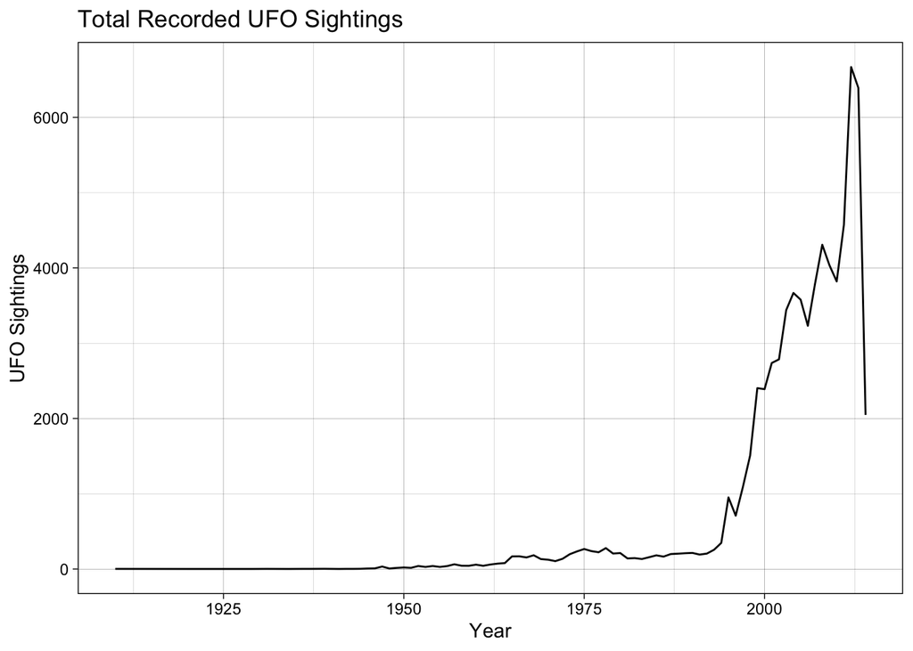

```r
ufo_total <- ufo %>% group_by(year(date_time)) %>% summarize(total = n())

names(ufo_total) <- c("year", "total") #this changes the variable names

ggplot(aes(x = year, y = total), data = ufo_total) + geom_line() +
  labs(x = "Year",
       y = "UFO Sightings",
       title = "Total Recorded UFO Sightings") +
  theme_linedraw()
```

Looks like UFO sightings have drastically increased in recent years. Is it more UFOs or better data reporting? I’ll let you decide…